# Glive

Domača naloga 4 - Znanstvena raziskava

Author

Miha Prajs

Published

May 17, 2024

Glive so starodavni in raznovrstni mikroorganizmi. So heterotrofni, prehranjujejo s lahko na simbionten, saprofitski ali parazitski način, uvščamo pa jih med evkarionte. Molekularni preizkusi kažejo, da so je skupni prednih+k gliv živel že v predkambriju (Carlile, Watkinson, and Gooday 2001).

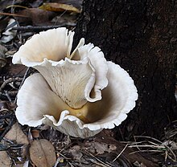

Figure 1: Gliva

```r
knitr::include_graphics("https://upload.wikimedia.org/wikipedia/commons/thumb/d/dd/Omphalotus_nidiformis_Binnamittalong_2_email.jpg/220px-Omphalotus_nidiformis_Binnamittalong_2_email.jpg")
```

## Zgradba gliv

**Glive** imajo vegetativno telo, ki je lahko zelo reducirano, nemicelijsko, nitasto ali okroglasto. Telo ločimo na površinsko (Slika 1) in notranje podgobje. Napram notranjem podgobju, se površinsko podgobje bolj razrašča in ima debelejše hife. Osnovni gradnik gliv je celica, le ta pa je sestavljena iz celične stene, celične membrane in protoplasta – citoplazme z ograneli. V citoplazmi se nahaja več organelov:

- Jedro
- Mitohondriji
- Ribosomi
- Endoplazemski retikulum
- Vakuola

V glivnih celicah najdemo podobnosti tako rastlinskim kot živalskim celicam, bistvena razlika v glivah pa je vsebnost hitina v celični steni. Tega najdemo le v še pri členonožcih (Jenišek 2007).

## Tokisčnost gliv

### Mikotoksini gliv

Šele v zadnjih 30 letih je bilo odkrito, da pogosto prisotne glive, ki rastejo v živilih, proizvajajo toksine, znane kot mikotoksini. V zgodovini so te toksini privedli do večjih epidemij tako pri ljudeh kot pri živalih. Mikotoksini so sekunadarni metaboliti, to pomeni, da nimajo nobene funkcije pri normalnem razvoju in rasti glive. So majhne molekule, ki jih človeški imunski sistem ne more zaznati. Glavna nevarnost v človeški prehrani torej izhaja iz naše nezmožnosti zaznave teh mikotoksinov. Toksični so lahko na štiri osnovne načine: akutna toksičnost, kronična toksičnost, mutagenost in teratogenost. Simptomi mikotoksinov so skoraj tako raznovrstni kot je raznovrstna njihova kemijska struktura, saj so lahko sestavljeni iz enega heterocikličnega obroča ali pa iz šest do osem neurejenih obročev. Nekateri mikotoksini lahko povzročijo malo simptomov pred smrtjo osebka, nekateri pa povzročijo *raka* (Pitt 2000).

### Uvoz podatkov

S pomočjo spodnje kode so bili uvoženi podatki in knjižnice, ki so bile upodabljene pri izdelavi domače naloge.

```r
libs<-c("janitor","writexl","tidyverse")
lapply(libs,library,character.only=T)
```

[output not shown]

```r
df<-read.csv("archive/mushroom_cleaned.csv")
```

### Analiza podatkov

```r
df <- df %>%
  clean_names() %>%
  rename(premer_klobuka=cap_diameter,oblika_klobuka=cap_shape,pritrditev_hif=gill_attachment,barva_hif=gill_color,visina_beta=stem_height,sirina_beta=stem_width,barva_beta=stem_color,sezona=season,strupenost=class)
df %>%
  select('Višina beta'=visina_beta,'Širina beta'=sirina_beta) %>%
  as_tibble() %>%
  head(20)
```

```
# A tibble: 20 × 2
   `Višina beta` `Širina beta`
           <dbl>         <int>
 1         3.81           1545
 2         3.81           1557
 3         3.61           1566
 4         3.79           1566
 5         3.71           1464
 6         3.78           1520
 7         3.84           1563
 8         3.68           1532
 9         3.77           1476
10         3.78           1581
11         3.70           1524
12         0.286          1311
13         1.19           1681
14         0.549          1220
15         0.254          1239
16         0.951          1445
17         0.604          1415
18         0.437          1150
19         0.596          1531
20         0.907          1603
```

Podatke iz zgornje tabele smo prikazali s pomočjo spodnjega grafa.

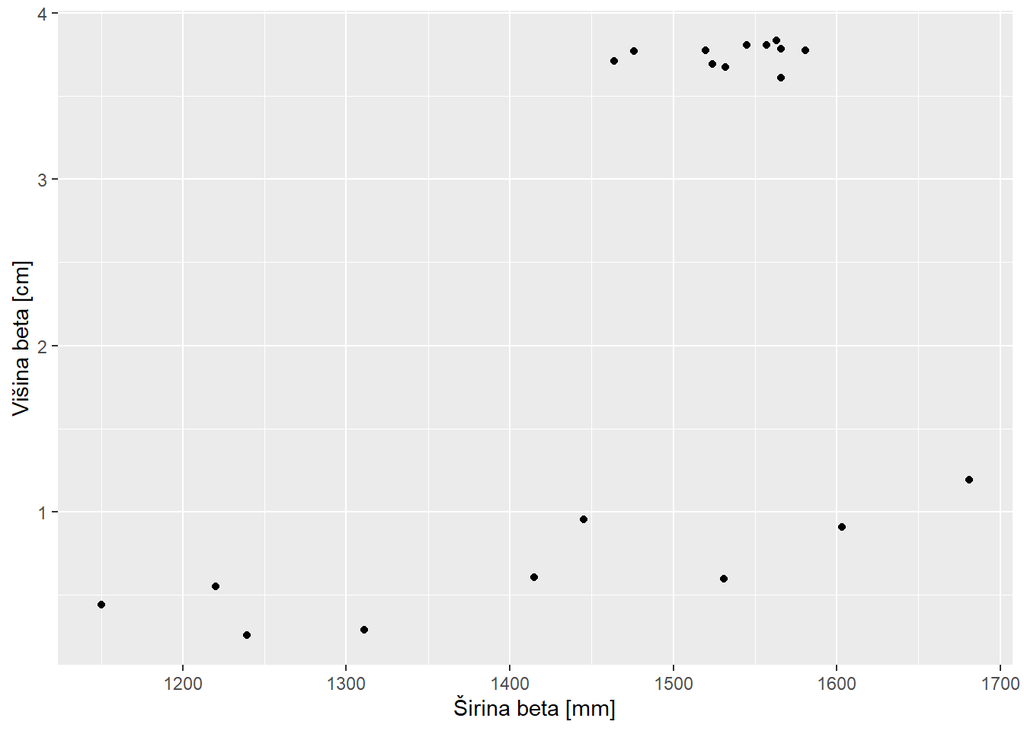

```r
df %>%
  head(20) %>%
  ggplot()+
  aes(y=visina_beta,x=sirina_beta)+
  geom_point()+
  xlab('Širina beta [mm]') +
  ylab('Višina beta [cm]')
```

```r
column1<-df %>%
  summarise('Širina beta'=mean(sirina_beta))
column2<-df %>%
  summarise('Višina beta'=mean(visina_beta))
```

Table 1: Povprečje širine in višine betov

| Širina beta | Višina beta |
| --- | --- |
| 1051.0812992 | 0.7591098 |

S pomočjo formule:
$$\frac{širina\ beta}{višina\ beta}=\frac{1}{x}$$
lahko izračunamo povprečje razmerje med širino in višino beta posameznih gob.

S formulo
$$\overline{x}=\frac{1}{n} \sum_{i=1}^{n} x_{i}$$
izračunamo povprečje vseh vrednosti posameznih spremenljivk (glej Tabelo 1).

## Opombe

Podatkovni okvir oz. “data frame” je bil pridobljen na spletni povezavi: https://www.kaggle.com/datasets/prishasawhney/mushroom-dataset, 14. maja 2024.

## Viri

Carlile, Michael J, Sarah C Watkinson, and Graham W Gooday. 2001. *The Fungi*. Gulf Professional Publishing.

Jenišek, Miran. 2007. “Uporaba Argona in Dušika Za Zaduševanje Lesnih Gliv : Diplomsko Delo (Univerzitetni Študij).” PhD thesis, M. Jenišek. https://repozitorij.uni-lj.si/IzpisGradiva.php?lang=slv&id=179.

Pitt, JI. 2000. “Toxigenic Fungi: Which Are Important?” *Sabouraudia* 38 (Supplement_1): 17–22.